# collegeOneRedo

Yakovlev D.M.

2024-12-01

# 1 Предварительный анализ данных

```r
library(tidyverse)
library(GGally)
library(ggplot2)
library(psych)
library(ggpubr)
library(patchwork)
library(kableExtra)
library(skimr)
```

```r
library(readxl)
col_I_sn<-read_excel("stat2021_sm\\us_col.std\\I_shortname.xls")
col_I<-read_excel("stat2021_sm\\us_col.std\\I.xls")
head(col_I_sn)|>rmarkdown::paged_table()
```

| ...1 | PPIND | FICE | STATE | TYPE | AVRMATH | AVRVERB | AVRCOMB | AVR_ACT | MATH_1 | MATH_3 | VERB_1 | VERB_3 | ACT_1 | ACT_3 | APP_REC | APP_ACC | NEW_STUD | NEW10 | NEW25 | FULLTIME | PARTTIME | IN_STATE | OUT_STAT | R_B_COST | ROOM | BOARD | ADD_FEE | BOOK | PERSONAL | … |
| --- | --- | --- | --- | --- | --- | --- | --- | --- | --- | --- | --- | --- | --- | --- | --- | --- | --- | --- | --- | --- | --- | --- | --- | --- | --- | --- | --- | --- | --- | --- |
| Auburn University-Ma | 1 | 1009 | AL | I | 575 | 501 | 1076 | 24 | 520 | 638 | 453 | 559 | 21 | 27 | 7548 | 6791 | 3070 | 25 | 57 | 16262 | 1716 | 2100 | 6300 | 3933 | NA | NA | NA | 600 | 1908 | … |
| University of Alabam | 1 | 1051 | AL | I | NA | NA | NA | 23 | NA | NA | NA | NA | 20 | 25 | 7593 | 5972 | 2682 | NA | 57 | 13780 | 1599 | 2172 | 5424 | 3530 | 1600 | 1930 | NA | 580 | 1654 | … |
| University of Alabam | 1 | 1052 | AL | I | NA | NA | NA | 21 | NA | NA | NA | NA | 18 | 24 | 1797 | 1260 | 938 | 24 | 35 | 6960 | 4698 | 2220 | 4440 | 5175 | 1935 | 3240 | 291 | 750 | 2200 | … |
| University of Alaska | 1 | 1063 | AK | I | 499 | 462 | 961 | 22 | NA | NA | NA | NA | NA | NA | 1852 | 1427 | 928 | NA | NA | 3885 | 4519 | 1742 | 5226 | 3590 | 1800 | 1790 | 155 | 650 | 2304 | … |
| Arizona State Univer | 1 | 1081 | AZ | I | 521 | 453 | 974 | 23 | 450 | 590 | 390 | 500 | 20 | 25 | 12809 | 10308 | 3761 | 24 | 49 | 22593 | 7585 | 1828 | 7434 | 4850 | NA | NA | 66 | 700 | 2100 | … |
| Northern Arizona Uni | 1 | 1082 | AZ | I | 495 | 444 | 939 | 22 | 420 | 560 | 380 | 500 | 19 | 24 | 5891 | 4931 | 1973 | 23 | 48 | 11249 | 2682 | 1828 | 6746 | 3728 | 1890 | 1838 | 66 | 620 | 2342 | … |

```r
summary(col_I_sn)
```

```
##      ...1               PPIND            FICE          STATE
##  Length:176         Min.   :1.000   Min.   : 1009   Length:176
##  Class :character   1st Qu.:1.000   1st Qu.: 1738   Class :character
##  Mode  :character   Median :1.000   Median : 2550   Mode  :character
##                     Mean   :1.301   Mean   : 2901
##                     3rd Qu.:2.000   3rd Qu.: 3417
##                     Max.   :2.000   Max.   :10366
##
##      TYPE              AVRMATH         AVRVERB         AVRCOMB
##  Length:176         Min.   :390.0   Min.   :391.0   Min.   : 810
##  Class :character   1st Qu.:520.0   1st Qu.:454.5   1st Qu.: 980
##  Mode  :character   Median :544.0   Median :479.5   Median :1017
##                     Mean   :563.5   Mean   :494.7   Mean   :1058
##                     3rd Qu.:603.0   3rd Qu.:518.5   3rd Qu.:1126
##                     Max.   :750.0   Max.   :665.0   Max.   :1410
##                     NA's   :68      NA's   :68      NA's   :67
##     AVR_ACT          MATH_1          MATH_3          VERB_1
##  Min.   :19.00   Min.   :350.0   Min.   :480.0   Min.   :320.0
##  1st Qu.:22.00   1st Qu.:460.0   1st Qu.:590.0   1st Qu.:400.0
##  Median :23.00   Median :500.0   Median :627.5   Median :430.0
##  Mean   :23.69   Mean   :515.4   Mean   :635.0   Mean   :448.3
##  3rd Qu.:25.00   3rd Qu.:570.0   3rd Qu.:687.5   3rd Qu.:480.0
##  Max.   :31.00   Max.   :740.0   Max.   :780.0   Max.   :630.0
##  NA's   :83      NA's   :34      NA's   :34      NA's   :34
##      VERB_3          ACT_1           ACT_3          APP_REC
##  Min.   :440.0   Min.   :16.00   Min.   :21.00   Min.   :  787
##  1st Qu.:520.0   1st Qu.:19.00   1st Qu.:25.00   1st Qu.: 4323
##  Median :550.0   Median :21.00   Median :26.00   Median : 7654
##  Mean   :561.3   Mean   :21.28   Mean   :26.55   Mean   : 8544
##  3rd Qu.:600.0   3rd Qu.:23.00   3rd Qu.:28.00   3rd Qu.:11776
##  Max.   :720.0   Max.   :29.00   Max.   :33.00   Max.   :48094
##  NA's   :34      NA's   :67      NA's   :67      NA's   :1
##     APP_ACC         NEW_STUD        NEW10           NEW25          FULLTIME
##  Min.   :  507   Min.   : 210   Min.   : 8.00   Min.   :24.00   Min.   :  912
##  1st Qu.: 3033   1st Qu.:1264   1st Qu.:24.00   1st Qu.:52.00   1st Qu.: 5846
##  Median : 4761   Median :1949   Median :32.00   Median :63.00   Median :10215
##  Mean   : 5546   Mean   :2252   Mean   :41.48   Mean   :65.55   Mean   :11296
##  3rd Qu.: 7232   3rd Qu.:3035   3rd Qu.:57.00   3rd Qu.:82.00   3rd Qu.:15033
##  Max.   :26330   Max.   :7425   Max.   :98.00   Max.   :99.00   Max.   :31643
##  NA's   :1                      NA's   :16      NA's   :26
```

[output cut: 41 more lines]

```
##  Min.   :395.0   Min.   : 436.0   Min.   : 39.0   Min.   : 32.0
##  1st Qu.:481.0   1st Qu.: 587.0   1st Qu.:184.5   1st Qu.:138.5
##  Median :508.5   Median : 652.0   Median :278.0   Median :208.0
##  Mean   :519.0   Mean   : 665.8   Mean   :336.8   Mean   :230.3
##  3rd Qu.:552.2   3rd Qu.: 730.2   3rd Qu.:457.8   3rd Qu.:299.0
##  Max.   :717.0   Max.   :1075.0   Max.   :997.0   Max.   :721.0
##                                                   NA's   :1
##      NUM_AS         NUM_INS          NUM_ALL
##  Min.   : 29.0   Min.   :  0.00   Min.   : 108.0
##  1st Qu.:128.5   1st Qu.:  5.00   1st Qu.: 505.5
##  Median :175.0   Median : 16.00   Median : 721.0
##  Mean   :190.7   Mean   : 27.09   Mean   : 812.8
##  3rd Qu.:238.2   3rd Qu.: 40.00   3rd Qu.:1035.0
##  Max.   :510.0   Max.   :178.00   Max.   :2261.0
##                  NA's   :1
```

```r
col_I_sn$PPIND=ifelse(col_I_sn$PPIND==1, "public", "private")
```

NA review

```r
col_I_sn_noNA<-col_I_sn|>na.omit()
paste("col_I_sn dim: ", paste(dim(col_I_sn),collapse=", "))
```

```
## [1] "col_I_sn dim:  176, 49"
```

```r
paste("col_I_sn_noNA dim: ", paste(dim(col_I_sn_noNA), collapse=", "))
```

```
## [1] "col_I_sn_noNA dim:  22, 49"
```

```r
naCol<-colSums(is.na(col_I_sn))|>sort(decreasing=TRUE)
naCol
```

```
##  AVR_ACT  AVRMATH  AVRVERB  AVRCOMB    ACT_1    ACT_3    BOARD     ROOM
##       83       68       68       67       67       67       64       42
##  ADD_FEE   MATH_1   MATH_3   VERB_1   VERB_3    NEW25    NEW10   TERM_D
##       40       34       34       34       34       26       16       16
##   DONATE PERSONAL     PH_D IN_STATE PARTTIME  GRADUAT     BOOK  APP_REC
##       12       11        9        7        6        5        2        1
##  APP_ACC OUT_STAT   NUM_AC  NUM_INS     ...1    PPIND     FICE    STATE
##        1        1        1        1        0        0        0        0
##     TYPE NEW_STUD FULLTIME R_B_COST SF_RATIO INSTRUCT SAL_FULL   SAL_AC
##        0        0        0        0        0        0        0        0
##   SAL_AS  SAL_ALL COMP_FUL  COMP_AC  COMP_AS COMP_ALL NUM_FULL   NUM_AS
##        0        0        0        0        0        0        0        0
##  NUM_ALL
##        0
```

```r
table(naCol)
```

```
## naCol
##  0  1  2  5  6  7  9 11 12 16 26 34 40 42 64 67 68 83
## 21  5  1  1  1  1  1  1  1  2  1  4  1  1  1  3  2  1
```

log dataset

```r
q_cols<-sapply(col_I_sn, is.numeric)
q_cols[c("PPIND", "FICE")]<-FALSE
q_cols<-names(q_cols)[q_cols==TRUE]

col_I_sn_log<-col_I_sn|>
  mutate(across(q_cols, ~log(.x)))|>
  rename_with(~paste0("log-", .x), q_cols)

head(col_I_sn_log)|>rmarkdown::paged_table()
```

| ...1 | PPIND | FICE | STATE | TYPE | log-AVRMATH | log-AVRVERB | log-AVRCOMB | log-AVR_ACT | log-MATH_1 | log-MATH_3 | log-VERB_1 | log-VERB_3 | log-ACT_1 | log-ACT_3 | log-APP_REC | log-APP_ACC | log-NEW_STUD | log-NEW10 | log-NEW25 | log-FULLTIME | log-PARTTIME | log-IN_STATE | log-OUT_STAT | log-R_B_COST | log-ROOM | log-BOARD | log-ADD_FEE | log-BOOK | log-PERSONAL | … |
| --- | --- | --- | --- | --- | --- | --- | --- | --- | --- | --- | --- | --- | --- | --- | --- | --- | --- | --- | --- | --- | --- | --- | --- | --- | --- | --- | --- | --- | --- | --- |
| Auburn University-Ma | public | 1009 | AL | I | 6.354370 | 6.216606 | 6.981006 | 3.178054 | 6.253829 | 6.458338 | 6.115892 | 6.326149 | 3.044522 | 3.295837 | 8.929038 | 8.823353 | 8.029433 | 3.218876 | 4.043051 | 9.696586 | 7.447751 | 7.649693 | 8.748305 | 8.277158 | NA | NA | NA | 6.396930 | 7.553811 | … |
| University of Alabam | public | 1051 | AL | I | NA | NA | NA | 3.135494 | NA | NA | NA | NA | 2.995732 | 3.218876 | 8.934982 | 8.694837 | 7.894318 | NA | 4.043051 | 9.530974 | 7.377134 | 7.683404 | 8.598589 | 8.169053 | 7.377759 | 7.565275 | NA | 6.363028 | 7.410952 | … |
| University of Alabam | public | 1052 | AL | I | NA | NA | NA | 3.044522 | NA | NA | NA | NA | 2.890372 | 3.178054 | 7.493874 | 7.138867 | 6.843750 | 3.178054 | 3.555348 | 8.847935 | 8.454892 | 7.705262 | 8.398410 | 8.551595 | 7.567863 | 8.083329 | 5.673323 | 6.620073 | 7.696213 | … |
| University of Alaska | public | 1063 | AK | I | 6.212606 | 6.135565 | 6.867974 | 3.091042 | NA | NA | NA | NA | NA | NA | 7.524021 | 7.263330 | 6.833032 | NA | NA | 8.264878 | 8.416046 | 7.462789 | 8.561401 | 8.185907 | 7.495542 | 7.489971 | 5.043425 | 6.476972 | 7.742402 | … |
| Arizona State Univer | public | 1081 | AZ | I | 6.255750 | 6.115892 | 6.881411 | 3.135494 | 6.109248 | 6.380123 | 5.966147 | 6.214608 | 2.995732 | 3.218876 | 9.457903 | 9.240676 | 8.232440 | 3.178054 | 3.891820 | 10.025395 | 8.933928 | 7.510978 | 8.913819 | 8.486734 | NA | NA | 4.189655 | 6.551080 | 7.649693 | … |
| Northern Arizona Uni | public | 1082 | AZ | I | 6.204558 | 6.095825 | 6.844815 | 3.091042 | 6.040255 | 6.327937 | 5.940171 | 6.214608 | 2.944439 | 3.178054 | 8.681181 | 8.503297 | 7.587311 | 3.135494 | 3.871201 | 9.328035 | 7.894318 | 7.510978 | 8.816705 | 8.223627 | 7.544332 | 7.516433 | 4.189655 | 6.429719 | 7.758761 | … |

Выделим основные признаки, по которым будет проходить дальнейший анализ данных

Количественные признаки:

- AVRMATH Average Math SAT score
- AVRVERB Average Verbal SAT score
- AVRCOMB Average Combined SAT score
- AVR_ACT Average ACT score
- MATH_1 First quartile - Math SAT
- MATH_3 Third quartile - Math SAT
- VERB_1 First quartile - Verbal SAT
- VERB_3 Third quartile - Verbal SAT
- ACT_1 First quartile - ACT
- ACT_3 Third quartile - ACT
- APP_REC Number of applications received
- APP_ACC Number of applicants accepted
- NEW_STUD Number of new students enrolled
- FULLTIME Number of fulltime undergraduates
- PARTTIME Number of parttime undergraduates
- IN_STATE In-state tuition
- OUT_STAT Out-of-state tuition
- R_B_COST Room and board costs
- ROOM Room costs
- BOARD Board costs
- ADD_FEE Additional fees
- BOOK Estimated book costs
- PERSONAL Estimated personal spending
- PH_D Pct. of faculty with Ph.D.’s
- TERM_D Pct. of faculty with terminal degree
- SAL_FULL Average salary - full professor
- SAL_AC Average salary - associate professor
- SAL_AS Average salary - assistant professor
- SAL_ALL Average salary - all ranks
- COMP_FUL Average compensation - full professor
- COMP_AC Average compensation - associate professor
- COMP_AS Average compensation - assistant professor
- COMP_ALL Average compensation - all ranks
- NUM_FULL Number of full professor
- NUM_AC Number of associate professor
- NUM_AS Number of assistant professor
- NUM_INS Number of instructors
- NUM_ALL Number of faculty - all ranks
- INSTRUCT Instructional expenditure per student
- GRADUAT Graduation rate
- SF_RATIO Student/faculty ratio
- DONATE Pct.alumni who donate
- NEW10 Pct. new students from top 10% of H.S. class - % студентов из топ 10% своей старшей школы
- NEW25 Pct. new students from top 25% of H.S. class - % студентов из топ 25% своей старшей школы

Качественные признаки:

- FICE - Federal ID Number
- …1 - Название университета
- PPIND Public/private indicator (public=1, private=2)
- STATE State (postal code)
- TYPE - I (можно удалить)

Всего 49 признаков. Отберём из условий задачи и по смыслу

NEW10 зависит от AVRMATH, MATH_1, MATH_3, AVRVERB, VERB_1, VERB_3, AVR_ACT, ACT_1, ACT_3 и AVRCOMB. Признаков много, так что выберем самый обобщающий - AVRCOMB

5. AVRCOMB
6. SF_RATIO
7. PH_D
8. GRADUAT 6-8 из предположения, что они взаимосвязаны
9. R_B_COST
10. IN_STATE
11. OUT_STAT 9-11 - зависимость стоимости проживания

Setup

```r
colNames<-c("ADD_FEE", "BOOK", "R_B_COST","IN_STATE","OUT_STAT","NEW10","AVRCOMB","SF_RATIO","PH_D","GRADUAT","PPIND")
colFin<-c("ADD_FEE", "BOOK", "PPIND")
colCost<-c("R_B_COST", "IN_STATE", "OUT_STAT", "PPIND")
colNew<-c("NEW10", "AVRCOMB", "PPIND")
colStud<-c("SF_RATIO", "PH_D", "GRADUAT", "PPIND")
col_I_comp<-col_I_sn[colNames]
col_I_comp_log<-col_I_sn_log[c(paste0("log-", colNames)[-length(colNames)], "PPIND")]
head(col_I_comp_log)|>rmarkdown::paged_table()
```

| log-ADD_FEE | log-BOOK | log-R_B_COST | log-IN_STATE | log-OUT_STAT | log-NEW10 | log-AVRCOMB | log-SF_RATIO | log-PH_D | log-GRADUAT | PPIND |
| --- | --- | --- | --- | --- | --- | --- | --- | --- | --- | --- |
| NA | 6.396930 | 8.277158 | 7.649693 | 8.748305 | 3.218876 | 6.981006 | 2.815409 | 4.442651 | 4.234107 | public |
| NA | 6.363028 | 8.169053 | 7.683404 | 8.598589 | NA | NA | 2.850707 | 4.382027 | 3.912023 | public |
| 5.673323 | 6.620073 | 8.551595 | 7.705262 | 8.398410 | 3.178054 | NA | 1.902108 | 4.564348 | 3.496508 | public |
| 5.043425 | 6.476972 | 8.185907 | 7.462789 | 8.561401 | NA | 6.867974 | 2.302585 | 4.204693 | NA | public |
| 4.189655 | 6.551080 | 8.486734 | 7.510978 | 8.913819 | 3.178054 | 6.881411 | 2.939162 | 4.477337 | 3.871201 | public |
| 4.189655 | 6.429719 | 8.223627 | 7.510978 | 8.816705 | 3.135494 | 6.844815 | 3.077312 | 4.356709 | 3.713572 | public |

Наблюдение: поскольку IN_STATE и OUT_STAT имеют линейную зависимость для частных вузов, а для общественных - нет, то можно предположить, что частные вузы не имеют разделения по стоимости обучения, а общественные имеют.

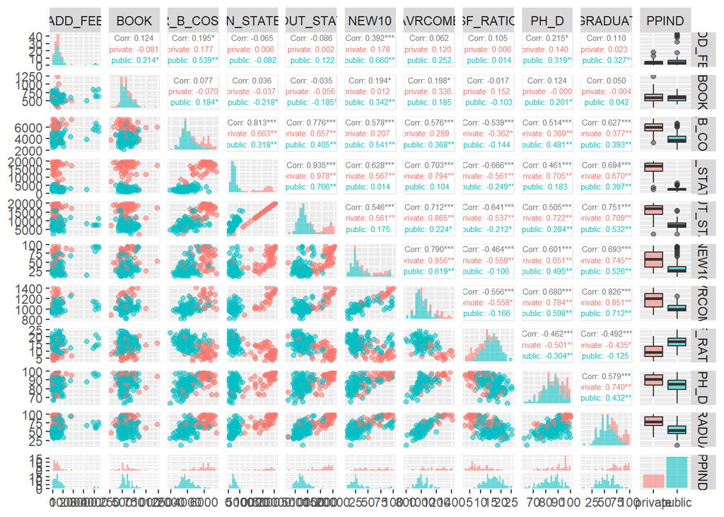

```r
ggpairs(col_I_comp, aes(alpha = 0.5, color=PPIND),
        diag = list(continuous = wrap("barDiag", bins = 20)),
        upper = list(continuous = wrap("cor", size = 2)))
```

Видим, что NEW10 зависит от PH_D, GRADUAT, AVRCOMB, отдельно для private зависит от OUT_STAT, IN_STATE, для public - от ADD_FEE, BOOK, R_B_COST

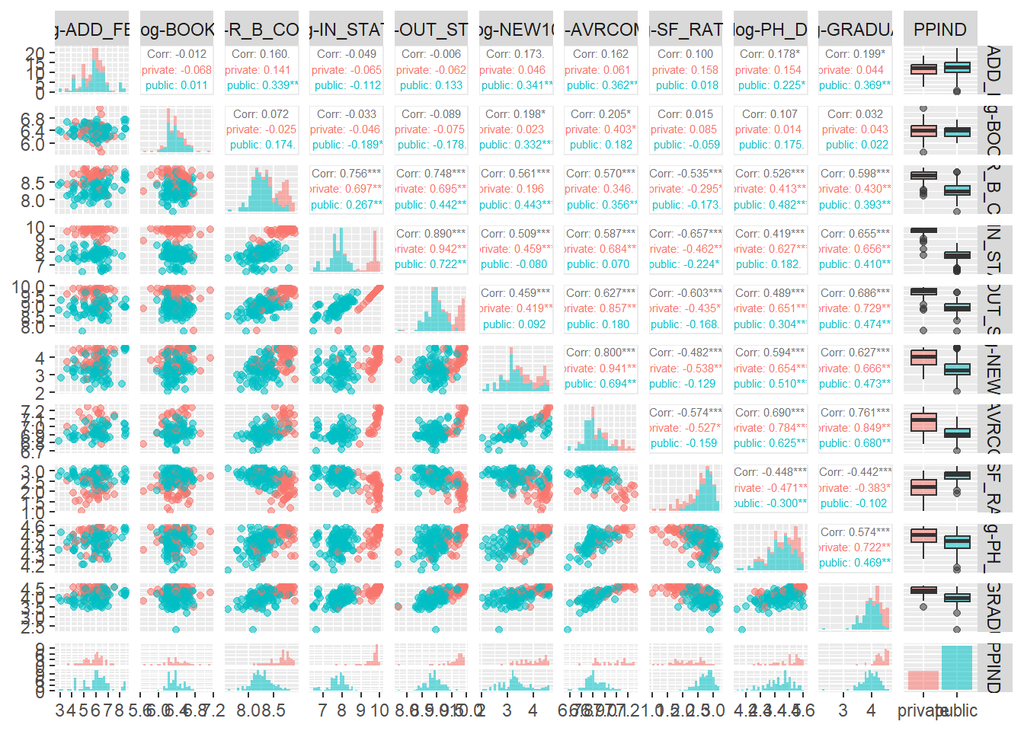

```r
ggpairs(col_I_comp_log, aes(alpha = 0.5, color=PPIND),
        diag = list(continuous = wrap("barDiag", bins = 20)),
        upper = list(continuous = wrap("cor", size = 2)))
```

Можно наблюдать явное разделение на две группы для R_B_COST, IN_STATE, OUT_STAT, NEW10. Понятно, что R_B_COST, IN_STATE, OUT_STAT и остальные признаки, связанные с финансами, зависят от того, в частном или общественном вузе проходит обучение. Вообще, университеты с низким показателем GRADUAT могут быть преимущественно ONLINE формата обучения.

Определим потенциальные выбросы

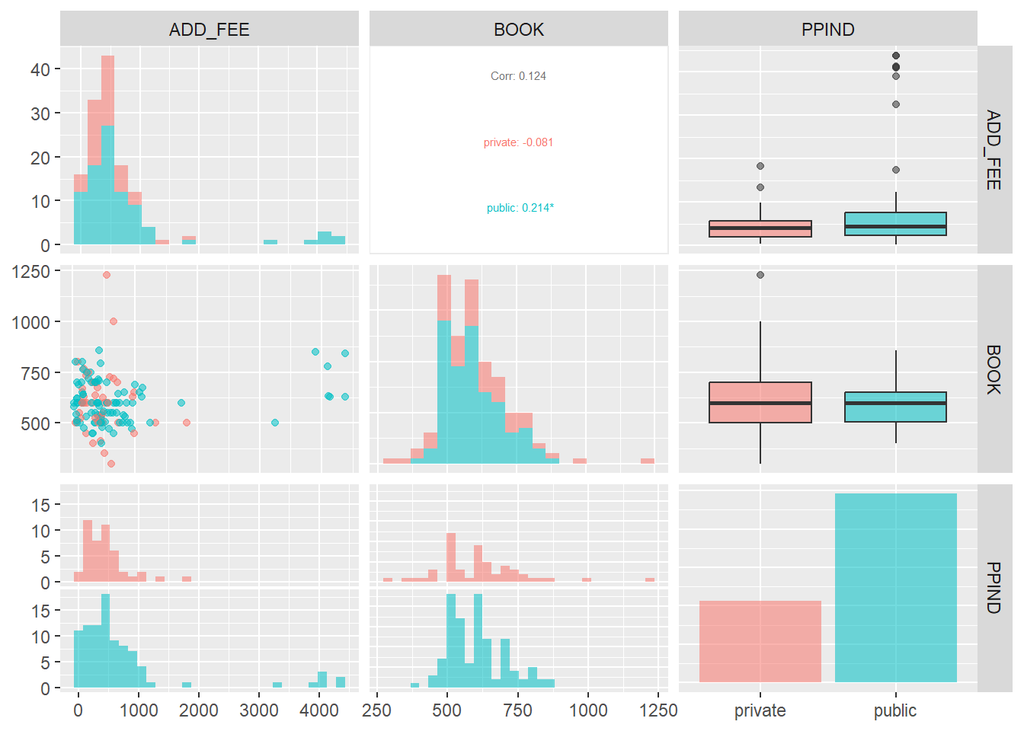

```r
ggpairs(col_I_comp[colFin], aes(alpha = 0.5, color=PPIND),
        diag = list(continuous = wrap("barDiag", bins = 20)),
        upper = list(continuous = wrap("cor", size = 2)))
```

На основном ggpairs можно заметить, что California и Massachusetts University имеют наибольший (с отрывом) ADD_FEE. Учитывая ВВП Калифорнии, это вероятно, для Массачусеттс не понятно, но на их сайте значения схожие. Оставим их.

```r
col_I_sn|>filter(BOOK>=900 | BOOK <= 350)
```

```
## # A tibble: 4 × 49
##   ...1     PPIND  FICE STATE TYPE  AVRMATH AVRVERB AVRCOMB AVR_ACT MATH_1 MATH_3
##   <chr>    <chr> <dbl> <chr> <chr>   <dbl>   <dbl>   <dbl>   <dbl>  <dbl>  <dbl>
## 1 Howard … priv…  1448 DC    I         457     426     883      20    390    510
## 2 Tulane … priv…  2029 LA    I          NA      NA      NA      NA    560    670
## 3 Hofstra… priv…  2732 NY    I         540     470    1010      24    480    590
## 4 Renssel… priv…  2803 NY    I          NA      NA      NA      28    610    710
## # ℹ 38 more variables: VERB_1 <dbl>, VERB_3 <dbl>, ACT_1 <dbl>, ACT_3 <dbl>,
## #   APP_REC <dbl>, APP_ACC <dbl>, NEW_STUD <dbl>, NEW10 <dbl>, NEW25 <dbl>,
## #   FULLTIME <dbl>, PARTTIME <dbl>, IN_STATE <dbl>, OUT_STAT <dbl>,
## #   R_B_COST <dbl>, ROOM <dbl>, BOARD <dbl>, ADD_FEE <dbl>, BOOK <dbl>,
## #   PERSONAL <dbl>, PH_D <dbl>, TERM_D <dbl>, SF_RATIO <dbl>, DONATE <dbl>,
## #   INSTRUCT <dbl>, GRADUAT <dbl>, SAL_FULL <dbl>, SAL_AC <dbl>, SAL_AS <dbl>,
## #   SAL_ALL <dbl>, COMP_FUL <dbl>, COMP_AC <dbl>, COMP_AS <dbl>, …
```

```r
col_I_sn|>filter(ADD_FEE>3000)
```

```
## # A tibble: 7 × 49
##   ...1     PPIND  FICE STATE TYPE  AVRMATH AVRVERB AVRCOMB AVR_ACT MATH_1 MATH_3
##   <chr>    <chr> <dbl> <chr> <chr>   <dbl>   <dbl>   <dbl>   <dbl>  <dbl>  <dbl>
## 1 Univers… publ…  1313 CA    I         585     485    1070      24    520    650
## 2 Univers… publ…  1315 CA    I         621     520    1141      NA    558    700
## 3 Univers… publ…  1316 CA    I         542     440     982      23    470    620
## 4 Univers… publ…  1317 CA    I         616     515    1131      26    560    680
## 5 Univers… publ…  1320 CA    I         547     459    1006      NA    520    610
## 6 Univers… publ…  1321 CA    I         554     505    1059      NA    490    620
## 7 Univers… publ…  2221 MA    I          NA      NA      NA      NA    460    590
## # ℹ 38 more variables: VERB_1 <dbl>, VERB_3 <dbl>, ACT_1 <dbl>, ACT_3 <dbl>,
## #   APP_REC <dbl>, APP_ACC <dbl>, NEW_STUD <dbl>, NEW10 <dbl>, NEW25 <dbl>,
## #   FULLTIME <dbl>, PARTTIME <dbl>, IN_STATE <dbl>, OUT_STAT <dbl>,
## #   R_B_COST <dbl>, ROOM <dbl>, BOARD <dbl>, ADD_FEE <dbl>, BOOK <dbl>,
## #   PERSONAL <dbl>, PH_D <dbl>, TERM_D <dbl>, SF_RATIO <dbl>, DONATE <dbl>,
## #   INSTRUCT <dbl>, GRADUAT <dbl>, SAL_FULL <dbl>, SAL_AC <dbl>, SAL_AS <dbl>,
## #   SAL_ALL <dbl>, COMP_FUL <dbl>, COMP_AC <dbl>, COMP_AS <dbl>, …
```

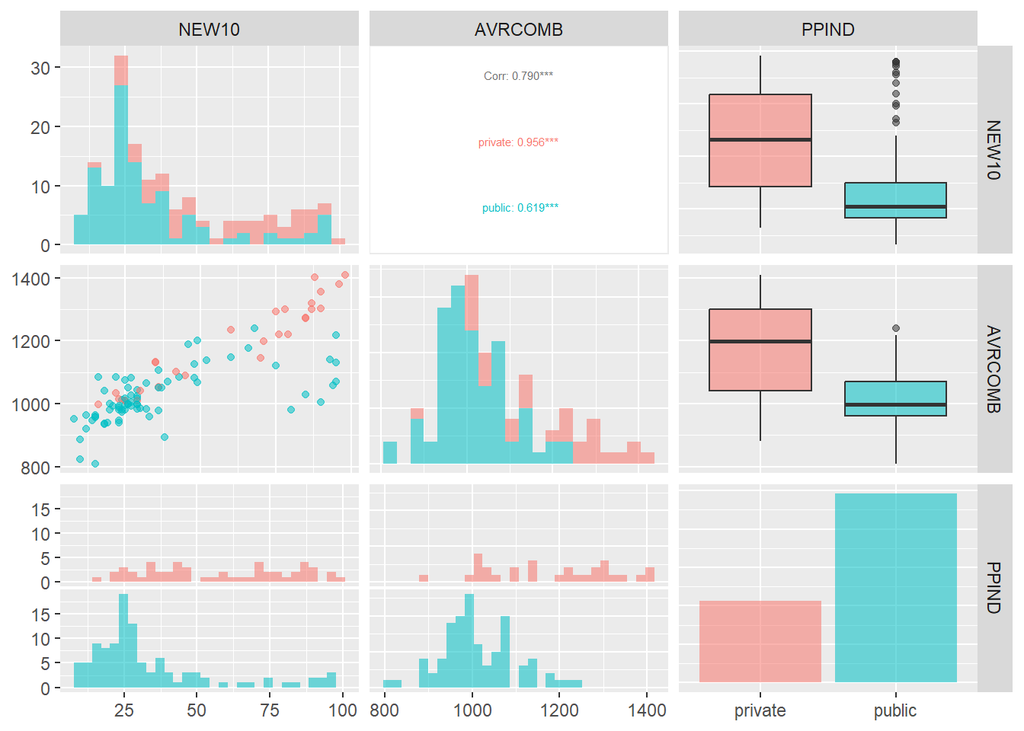

```r
ggpairs(col_I_comp[colNew], aes(alpha = 0.5, color=PPIND),
        diag = list(continuous = wrap("barDiag", bins = 20)),
        upper = list(continuous = wrap("cor", size = 2)))
```

Здесь тоже выброс осуществляет California University вместе с North Carolina University. Оставляем.

```r
col_I_sn|>filter(AVRCOMB<=1200 & NEW10>=75)
```

```
## # A tibble: 8 × 49
##   ...1     PPIND  FICE STATE TYPE  AVRMATH AVRVERB AVRCOMB AVR_ACT MATH_1 MATH_3
##   <chr>    <chr> <dbl> <chr> <chr>   <dbl>   <dbl>   <dbl>   <dbl>  <dbl>  <dbl>
## 1 Univers… publ…  1313 CA    I         585     485    1070      24    520    650
## 2 Univers… publ…  1314 CA    I         574     455    1029      NA    510    640
## 3 Univers… publ…  1315 CA    I         621     520    1141      NA    558    700
## 4 Univers… publ…  1316 CA    I         542     440     982      23    470    620
## 5 Univers… publ…  1317 CA    I         616     515    1131      26    560    680
## 6 Univers… publ…  1320 CA    I         547     459    1006      NA    520    610
## 7 Univers… publ…  1321 CA    I         554     505    1059      NA    490    620
## 8 Univers… publ…  2974 NC    I         594     527    1121      NA    530    530
## # ℹ 38 more variables: VERB_1 <dbl>, VERB_3 <dbl>, ACT_1 <dbl>, ACT_3 <dbl>,
## #   APP_REC <dbl>, APP_ACC <dbl>, NEW_STUD <dbl>, NEW10 <dbl>, NEW25 <dbl>,
## #   FULLTIME <dbl>, PARTTIME <dbl>, IN_STATE <dbl>, OUT_STAT <dbl>,
## #   R_B_COST <dbl>, ROOM <dbl>, BOARD <dbl>, ADD_FEE <dbl>, BOOK <dbl>,
## #   PERSONAL <dbl>, PH_D <dbl>, TERM_D <dbl>, SF_RATIO <dbl>, DONATE <dbl>,
## #   INSTRUCT <dbl>, GRADUAT <dbl>, SAL_FULL <dbl>, SAL_AC <dbl>, SAL_AS <dbl>,
## #   SAL_ALL <dbl>, COMP_FUL <dbl>, COMP_AC <dbl>, COMP_AS <dbl>, …
```

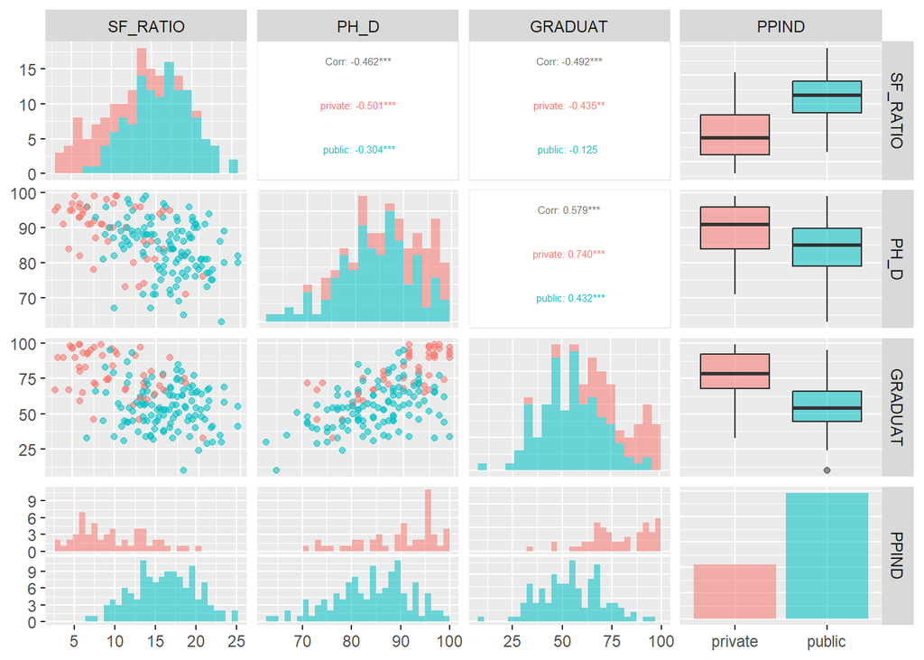

```r
ggpairs(col_I_comp[colStud], aes(alpha = 0.5, color=PPIND),
        diag = list(continuous = wrap("barDiag", bins = 20)),
        upper = list(continuous = wrap("cor", size = 2)))
```

Можно заметить, что PH_D более дискретизирован (по вертикальным прямым на скаттерплоте) для частных вузов, чем для общественных.

```r
col_I_sn|>filter(PH_D<=70)
```

```
## # A tibble: 5 × 49
##   ...1     PPIND  FICE STATE TYPE  AVRMATH AVRVERB AVRCOMB AVR_ACT MATH_1 MATH_3
##   <chr>    <chr> <dbl> <chr> <chr>   <dbl>   <dbl>   <dbl>   <dbl>  <dbl>  <dbl>
## 1 Univers… publ…  1063 AK    I         499     462     961      22     NA     NA
## 2 Ball St… publ…  1786 IN    I         473     422     895      21    400    530
## 3 Univers… publ…  2031 LA    I          NA      NA      NA      19     NA     NA
## 4 Texas S… publ…  3642 TX    I         390     420     810      19     NA     NA
## 5 Texas W… publ…  3646 TX    I          NA      NA      NA      NA    350    480
## # ℹ 38 more variables: VERB_1 <dbl>, VERB_3 <dbl>, ACT_1 <dbl>, ACT_3 <dbl>,
## #   APP_REC <dbl>, APP_ACC <dbl>, NEW_STUD <dbl>, NEW10 <dbl>, NEW25 <dbl>,
## #   FULLTIME <dbl>, PARTTIME <dbl>, IN_STATE <dbl>, OUT_STAT <dbl>,
## #   R_B_COST <dbl>, ROOM <dbl>, BOARD <dbl>, ADD_FEE <dbl>, BOOK <dbl>,
## #   PERSONAL <dbl>, PH_D <dbl>, TERM_D <dbl>, SF_RATIO <dbl>, DONATE <dbl>,
## #   INSTRUCT <dbl>, GRADUAT <dbl>, SAL_FULL <dbl>, SAL_AC <dbl>, SAL_AS <dbl>,
## #   SAL_ALL <dbl>, COMP_FUL <dbl>, COMP_AC <dbl>, COMP_AS <dbl>, …
```

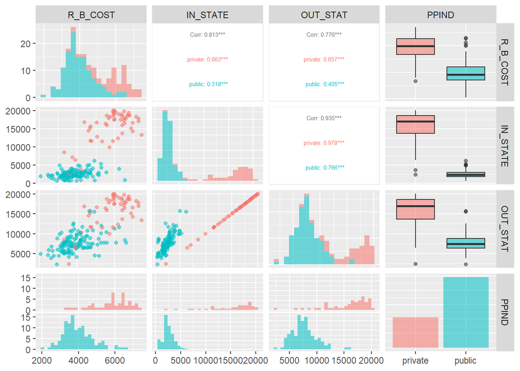

```r
ggpairs(col_I_comp[colCost], aes(alpha = 0.5, color=PPIND),
        diag = list(continuous = wrap("barDiag", bins = 20)),
        upper = list(continuous = wrap("cor", size = 2)))
```

```r
col_I_sn|>filter(OUT_STAT>=14000 & PPIND=="public")
```

```
## # A tibble: 2 × 49
##   ...1     PPIND  FICE STATE TYPE  AVRMATH AVRVERB AVRCOMB AVR_ACT MATH_1 MATH_3
##   <chr>    <chr> <dbl> <chr> <chr>   <dbl>   <dbl>   <dbl>   <dbl>  <dbl>  <dbl>
## 1 Univers… publ…  3696 VT    I         553     488    1041      NA    500    610
## 2 Univers… publ…  9092 MI    I         634     543    1177      27    580    700
## # ℹ 38 more variables: VERB_1 <dbl>, VERB_3 <dbl>, ACT_1 <dbl>, ACT_3 <dbl>,
## #   APP_REC <dbl>, APP_ACC <dbl>, NEW_STUD <dbl>, NEW10 <dbl>, NEW25 <dbl>,
## #   FULLTIME <dbl>, PARTTIME <dbl>, IN_STATE <dbl>, OUT_STAT <dbl>,
## #   R_B_COST <dbl>, ROOM <dbl>, BOARD <dbl>, ADD_FEE <dbl>, BOOK <dbl>,
## #   PERSONAL <dbl>, PH_D <dbl>, TERM_D <dbl>, SF_RATIO <dbl>, DONATE <dbl>,
## #   INSTRUCT <dbl>, GRADUAT <dbl>, SAL_FULL <dbl>, SAL_AC <dbl>, SAL_AS <dbl>,
## #   SAL_ALL <dbl>, COMP_FUL <dbl>, COMP_AC <dbl>, COMP_AS <dbl>, …
```

```r
col_I_sn|>filter(OUT_STAT<=10500 & PPIND=="private")
```

```
## # A tibble: 6 × 49
##   ...1     PPIND  FICE STATE TYPE  AVRMATH AVRVERB AVRCOMB AVR_ACT MATH_1 MATH_3
##   <chr>    <chr> <dbl> <chr> <chr>   <dbl>   <dbl>   <dbl>   <dbl>  <dbl>  <dbl>
## 1 Univers… priv…  1431 DE    I          NA      NA    1035      NA    500    610
## 2 Howard … priv…  1448 DC    I         457     426     883      20    390    510
## 3 Rice Un… priv…  3604 TX    I          NA      NA      NA      NA    665    763
## 4 Texas C… priv…  3636 TX    I          NA      NA      NA      NA    460    600
## 5 Brigham… priv…  3670 UT    I          NA      NA      NA      NA     NA     NA
## 6 Baylor … priv…  6967 TX    I          NA      NA      NA      NA    500    620
## # ℹ 38 more variables: VERB_1 <dbl>, VERB_3 <dbl>, ACT_1 <dbl>, ACT_3 <dbl>,
## #   APP_REC <dbl>, APP_ACC <dbl>, NEW_STUD <dbl>, NEW10 <dbl>, NEW25 <dbl>,
## #   FULLTIME <dbl>, PARTTIME <dbl>, IN_STATE <dbl>, OUT_STAT <dbl>,
## #   R_B_COST <dbl>, ROOM <dbl>, BOARD <dbl>, ADD_FEE <dbl>, BOOK <dbl>,
## #   PERSONAL <dbl>, PH_D <dbl>, TERM_D <dbl>, SF_RATIO <dbl>, DONATE <dbl>,
## #   INSTRUCT <dbl>, GRADUAT <dbl>, SAL_FULL <dbl>, SAL_AC <dbl>, SAL_AS <dbl>,
## #   SAL_ALL <dbl>, COMP_FUL <dbl>, COMP_AC <dbl>, COMP_AS <dbl>, …
```

У Brigham Young University очень низкий показатель OUT-STAT. Сам университет располагается в штате Utah, где ВВП невысокий. Оставляем.

Замечаем, что процент выпускников в частных вузах больше, чем в общественных, а также, что NEW10 больше - в частные школы поступает больше из 10% лучших школы. Обратим внимание на SF_RATIO - в общественных вузах больше студентов на преподавателя, чем в частных вузах, что может сказываться на качестве образования. Число PH_D примерно одинаковое.

Обратим внимание на линейную зависимость между IN_STATE и OUT_STAT. Для частных вузов стоимость линейно зависима, так как затраты на обучение производятся без государственных субсидий, что характерно для общественных вузов.

10. Descriptive analysis

```r
results <- describeBy(col_I_comp, group=col_I_comp$PPIND)

df_results <- map_dfr(results, ~as.data.frame(.x), .id = "group")

kable(df_results, "html") %>%
  kable_styling(full_width = FALSE) %>%
  scroll_box(width = "100%", height = "400px")
```

|  | group | vars | n | mean | sd | median | trimmed | mad | min | max | range | skew | kurtosis | se |
| --- | --- | --- | --- | --- | --- | --- | --- | --- | --- | --- | --- | --- | --- | --- |
| ADD_FEE…1 | private | 1 | 46 | 451.934783 | 345.880416 | 405.0 | 403.842105 | 289.10700 | 40.0 | 1836.0 | 1796.0 | 1.7753185 | 4.1159323 | 50.9972852 |
| BOOK…2 | private | 2 | 53 | 610.075472 | 158.110946 | 600.0 | 597.534884 | 148.26000 | 300.0 | 1230.0 | 930.0 | 1.2325851 | 3.0965764 | 21.7182087 |
| R_B_COST…3 | private | 3 | 53 | 5839.811321 | 997.070479 | 5975.0 | 5922.255814 | 816.91260 | 3320.0 | 7425.0 | 4105.0 | -0.7233444 | -0.2295138 | 136.9581633 |
| IN_STATE…4 | private | 4 | 53 | 15624.150943 | 4194.954650 | 17020.0 | 16299.906977 | 2772.46200 | 2340.0 | 20100.0 | 17760.0 | -1.3898856 | 1.3723903 | 576.2213365 |
| OUT_STAT…5 | private | 5 | 53 | 15747.358491 | 3924.905335 | 17020.0 | 16306.186047 | 2772.46200 | 2340.0 | 20100.0 | 17760.0 | -1.3082365 | 1.3192370 | 539.1272103 |
| NEW10…6 | private | 6 | 52 | 57.788461 | 24.379625 | 58.0 | 57.761905 | 33.35850 | 16.0 | 98.0 | 82.0 | 0.0381849 | -1.4295240 | 3.3808458 |
| AVRCOMB…7 | private | 7 | 29 | 1177.034483 | 144.286046 | 1199.0 | 1177.680000 | 161.60340 | 883.0 | 1410.0 | 527.0 | -0.0893581 | -1.2296542 | 26.7932461 |
| SF_RATIO…8 | private | 8 | 53 | 9.813208 | 4.326885 | 9.2 | 9.555814 | 4.89258 | 2.9 | 20.5 | 17.6 | 0.4758614 | -0.7282486 | 0.5943434 |
| PH_D…9 | private | 9 | 49 | 89.591837 | 7.865850 | 91.0 | 90.317073 | 7.41300 | 71.0 | 99.0 | 28.0 | -0.8078233 | -0.4898133 | 1.1236929 |
| GRADUAT…10 | private | 10 | 52 | 78.711539 | 15.753414 | 78.5 | 80.023809 | 17.79120 | 33.0 | 99.0 | 66.0 | -0.6127581 | -0.1790876 | 2.1846055 |
| PPIND…11 | private | 11 | 53 | 1.000000 | 0.000000 | 1.0 | 1.000000 | 0.00000 | 1.0 | 1.0 | 0.0 | NaN | NaN | 0.0000000 |
| ADD_FEE…12 | public | 1 | 90 | 748.388889 | 1015.494917 | 443.0 | 495.569444 | 404.00850 | 20.0 | 4374.0 | 4354.0 | 2.6479006 | 6.0998551 | 107.0425630 |
| BOOK…13 | public | 2 | 121 | 600.008264 | 101.162122 | 600.0 | 591.103093 | 111.19500 | 400.0 | 858.0 | 458.0 | 0.6447669 | -0.2889320 | 9.1965565 |
| R_B_COST…14 | public | 3 | 123 | 3977.073171 | 842.490474 | 3811.0 | 3911.979798 | 722.02620 | 2082.0 | 6607.0 | 4525.0 | 0.7886999 | 0.7902446 | 75.9648078 |
| IN_STATE…15 | public | 4 | 116 | 2537.137931 | 1078.590561 | 2408.0 | 2479.372340 | 877.69920 | 647.0 | 6210.0 | 5563.0 | 0.6645711 | 0.6461950 | 100.1446195 |
| OUT_STAT…16 | public | 5 | 122 | 7657.549180 | 2252.312472 | 7446.5 | 7517.163265 | 1939.24080 | 2279.0 | 15732.0 | 13453.0 | 0.7771996 | 1.2996173 | 203.9147900 |
| NEW10…17 | public | 6 | 108 | 33.620370 | 21.866937 | 26.0 | 29.920455 | 11.86080 | 8.0 | 95.0 | 87.0 | 1.5420644 | 1.5799521 | 2.1041470 |
| AVRCOMB…18 | public | 7 | 80 | 1014.662500 | 84.658651 | 997.0 | 1010.687500 | 75.61260 | 810.0 | 1240.0 | 430.0 | 0.4180047 | 0.1997793 | 9.4651249 |
| SF_RATIO…19 | public | 8 | 123 | 16.129268 | 3.830202 | 16.5 | 16.178788 | 4.15128 | 6.7 | 24.7 | 18.0 | -0.0994206 | -0.5699091 | 0.3453577 |
| PH_D…20 | public | 9 | 118 | 84.110169 | 7.798514 | 85.0 | 84.406250 | 7.41300 | 63.0 | 99.0 | 36.0 | -0.3698537 | -0.3490528 | 0.7179114 |
| GRADUAT…21 | public | 10 | 119 | 54.731092 | 15.573063 | 54.0 | 54.412371 | 16.30860 | 10.0 | 95.0 | 85.0 | 0.1127780 | -0.1892703 | 1.4275804 |
| PPIND…22 | public | 11 | 123 | 2.000000 | 0.000000 | 2.0 | 2.000000 | 0.00000 | 2.0 | 2.0 | 0.0 | NaN | NaN | 0.0000000 |

### 1.0.1 Выводы:

##### 1.0.1.0.1 Выбросы:

- AVRCOMB/NEW10: California University и North Carolina University. Оставляем (данные корректны).

```r
col_I_sn|>filter(AVRCOMB<=1200 & NEW10>=75)
```

```
## # A tibble: 8 × 49
##   ...1     PPIND  FICE STATE TYPE  AVRMATH AVRVERB AVRCOMB AVR_ACT MATH_1 MATH_3
##   <chr>    <chr> <dbl> <chr> <chr>   <dbl>   <dbl>   <dbl>   <dbl>  <dbl>  <dbl>
## 1 Univers… publ…  1313 CA    I         585     485    1070      24    520    650
## 2 Univers… publ…  1314 CA    I         574     455    1029      NA    510    640
## 3 Univers… publ…  1315 CA    I         621     520    1141      NA    558    700
## 4 Univers… publ…  1316 CA    I         542     440     982      23    470    620
## 5 Univers… publ…  1317 CA    I         616     515    1131      26    560    680
## 6 Univers… publ…  1320 CA    I         547     459    1006      NA    520    610
## 7 Univers… publ…  1321 CA    I         554     505    1059      NA    490    620
## 8 Univers… publ…  2974 NC    I         594     527    1121      NA    530    530
## # ℹ 38 more variables: VERB_1 <dbl>, VERB_3 <dbl>, ACT_1 <dbl>, ACT_3 <dbl>,
## #   APP_REC <dbl>, APP_ACC <dbl>, NEW_STUD <dbl>, NEW10 <dbl>, NEW25 <dbl>,
## #   FULLTIME <dbl>, PARTTIME <dbl>, IN_STATE <dbl>, OUT_STAT <dbl>,
## #   R_B_COST <dbl>, ROOM <dbl>, BOARD <dbl>, ADD_FEE <dbl>, BOOK <dbl>,
## #   PERSONAL <dbl>, PH_D <dbl>, TERM_D <dbl>, SF_RATIO <dbl>, DONATE <dbl>,
## #   INSTRUCT <dbl>, GRADUAT <dbl>, SAL_FULL <dbl>, SAL_AC <dbl>, SAL_AS <dbl>,
## #   SAL_ALL <dbl>, COMP_FUL <dbl>, COMP_AC <dbl>, COMP_AS <dbl>, …
```

- PH_D: более дискретизирован (по вертикальным прямым на скаттерплоте) для частных вузов, чем для общественных.

```r
col_I_sn|>filter(PH_D<=70)
```

```
## # A tibble: 5 × 49
##   ...1     PPIND  FICE STATE TYPE  AVRMATH AVRVERB AVRCOMB AVR_ACT MATH_1 MATH_3
##   <chr>    <chr> <dbl> <chr> <chr>   <dbl>   <dbl>   <dbl>   <dbl>  <dbl>  <dbl>
## 1 Univers… publ…  1063 AK    I         499     462     961      22     NA     NA
## 2 Ball St… publ…  1786 IN    I         473     422     895      21    400    530
## 3 Univers… publ…  2031 LA    I          NA      NA      NA      19     NA     NA
## 4 Texas S… publ…  3642 TX    I         390     420     810      19     NA     NA
## 5 Texas W… publ…  3646 TX    I          NA      NA      NA      NA    350    480
## # ℹ 38 more variables: VERB_1 <dbl>, VERB_3 <dbl>, ACT_1 <dbl>, ACT_3 <dbl>,
## #   APP_REC <dbl>, APP_ACC <dbl>, NEW_STUD <dbl>, NEW10 <dbl>, NEW25 <dbl>,
## #   FULLTIME <dbl>, PARTTIME <dbl>, IN_STATE <dbl>, OUT_STAT <dbl>,
## #   R_B_COST <dbl>, ROOM <dbl>, BOARD <dbl>, ADD_FEE <dbl>, BOOK <dbl>,
## #   PERSONAL <dbl>, PH_D <dbl>, TERM_D <dbl>, SF_RATIO <dbl>, DONATE <dbl>,
## #   INSTRUCT <dbl>, GRADUAT <dbl>, SAL_FULL <dbl>, SAL_AC <dbl>, SAL_AS <dbl>,
## #   SAL_ALL <dbl>, COMP_FUL <dbl>, COMP_AC <dbl>, COMP_AS <dbl>, …
```

- OUT_STAT: У Brigham Young University очень низкий показатель OUT-STAT. Сам университет располагается в штате Utah, где ВВП невысокий. Для private низкое ценообразование можно обосновать низким GRADUAT и NEW10

```r
col_I_sn|>filter((OUT_STAT>=14000 & PPIND=="public") | (OUT_STAT<=10500 & PPIND=="private"))
```

```
## # A tibble: 8 × 49
##   ...1     PPIND  FICE STATE TYPE  AVRMATH AVRVERB AVRCOMB AVR_ACT MATH_1 MATH_3
##   <chr>    <chr> <dbl> <chr> <chr>   <dbl>   <dbl>   <dbl>   <dbl>  <dbl>  <dbl>
## 1 Univers… priv…  1431 DE    I          NA      NA    1035      NA    500    610
## 2 Howard … priv…  1448 DC    I         457     426     883      20    390    510
## 3 Rice Un… priv…  3604 TX    I          NA      NA      NA      NA    665    763
## 4 Texas C… priv…  3636 TX    I          NA      NA      NA      NA    460    600
## 5 Brigham… priv…  3670 UT    I          NA      NA      NA      NA     NA     NA
## 6 Univers… publ…  3696 VT    I         553     488    1041      NA    500    610
## 7 Baylor … priv…  6967 TX    I          NA      NA      NA      NA    500    620
## 8 Univers… publ…  9092 MI    I         634     543    1177      27    580    700
## # ℹ 38 more variables: VERB_1 <dbl>, VERB_3 <dbl>, ACT_1 <dbl>, ACT_3 <dbl>,
## #   APP_REC <dbl>, APP_ACC <dbl>, NEW_STUD <dbl>, NEW10 <dbl>, NEW25 <dbl>,
## #   FULLTIME <dbl>, PARTTIME <dbl>, IN_STATE <dbl>, OUT_STAT <dbl>,
## #   R_B_COST <dbl>, ROOM <dbl>, BOARD <dbl>, ADD_FEE <dbl>, BOOK <dbl>,
## #   PERSONAL <dbl>, PH_D <dbl>, TERM_D <dbl>, SF_RATIO <dbl>, DONATE <dbl>,
## #   INSTRUCT <dbl>, GRADUAT <dbl>, SAL_FULL <dbl>, SAL_AC <dbl>, SAL_AS <dbl>,
## #   SAL_ALL <dbl>, COMP_FUL <dbl>, COMP_AC <dbl>, COMP_AS <dbl>, …
```

- ADD_FEE/BOOK: можно заметить, что California и Massachusetts University имеют наибольший (с отрывом) ADD_FEE. Учитывая ВВП Калифорнии, это вероятно, для Массачусеттс не понятно, но на их сайте значения схожие.

```r
col_I_sn|>filter(BOOK>=900 | BOOK <= 350)
```

```
## # A tibble: 4 × 49
##   ...1     PPIND  FICE STATE TYPE  AVRMATH AVRVERB AVRCOMB AVR_ACT MATH_1 MATH_3
##   <chr>    <chr> <dbl> <chr> <chr>   <dbl>   <dbl>   <dbl>   <dbl>  <dbl>  <dbl>
## 1 Howard … priv…  1448 DC    I         457     426     883      20    390    510
## 2 Tulane … priv…  2029 LA    I          NA      NA      NA      NA    560    670
## 3 Hofstra… priv…  2732 NY    I         540     470    1010      24    480    590
## 4 Renssel… priv…  2803 NY    I          NA      NA      NA      28    610    710
## # ℹ 38 more variables: VERB_1 <dbl>, VERB_3 <dbl>, ACT_1 <dbl>, ACT_3 <dbl>,
## #   APP_REC <dbl>, APP_ACC <dbl>, NEW_STUD <dbl>, NEW10 <dbl>, NEW25 <dbl>,
## #   FULLTIME <dbl>, PARTTIME <dbl>, IN_STATE <dbl>, OUT_STAT <dbl>,
## #   R_B_COST <dbl>, ROOM <dbl>, BOARD <dbl>, ADD_FEE <dbl>, BOOK <dbl>,
## #   PERSONAL <dbl>, PH_D <dbl>, TERM_D <dbl>, SF_RATIO <dbl>, DONATE <dbl>,
## #   INSTRUCT <dbl>, GRADUAT <dbl>, SAL_FULL <dbl>, SAL_AC <dbl>, SAL_AS <dbl>,
## #   SAL_ALL <dbl>, COMP_FUL <dbl>, COMP_AC <dbl>, COMP_AS <dbl>, …
```

```r
col_I_sn|>filter(ADD_FEE>=3000)
```

```
## # A tibble: 7 × 49
##   ...1     PPIND  FICE STATE TYPE  AVRMATH AVRVERB AVRCOMB AVR_ACT MATH_1 MATH_3
##   <chr>    <chr> <dbl> <chr> <chr>   <dbl>   <dbl>   <dbl>   <dbl>  <dbl>  <dbl>
## 1 Univers… publ…  1313 CA    I         585     485    1070      24    520    650
## 2 Univers… publ…  1315 CA    I         621     520    1141      NA    558    700
## 3 Univers… publ…  1316 CA    I         542     440     982      23    470    620
## 4 Univers… publ…  1317 CA    I         616     515    1131      26    560    680
## 5 Univers… publ…  1320 CA    I         547     459    1006      NA    520    610
## 6 Univers… publ…  1321 CA    I         554     505    1059      NA    490    620
## 7 Univers… publ…  2221 MA    I          NA      NA      NA      NA    460    590
## # ℹ 38 more variables: VERB_1 <dbl>, VERB_3 <dbl>, ACT_1 <dbl>, ACT_3 <dbl>,
## #   APP_REC <dbl>, APP_ACC <dbl>, NEW_STUD <dbl>, NEW10 <dbl>, NEW25 <dbl>,
## #   FULLTIME <dbl>, PARTTIME <dbl>, IN_STATE <dbl>, OUT_STAT <dbl>,
## #   R_B_COST <dbl>, ROOM <dbl>, BOARD <dbl>, ADD_FEE <dbl>, BOOK <dbl>,
## #   PERSONAL <dbl>, PH_D <dbl>, TERM_D <dbl>, SF_RATIO <dbl>, DONATE <dbl>,
## #   INSTRUCT <dbl>, GRADUAT <dbl>, SAL_FULL <dbl>, SAL_AC <dbl>, SAL_AS <dbl>,
## #   SAL_ALL <dbl>, COMP_FUL <dbl>, COMP_AC <dbl>, COMP_AS <dbl>, …
```

##### 1.0.1.0.2 Фиктивный признак IN_STATE.

По смыслу зависит от параметров (гос.субсидии), которых нет в данных, поэтому его сравнение с другими признаками не будет информативным.